# macrotopicsA_chapter2_3

```python
class Models:
    def __init__(self,β:float,γ:float,rent:float,nw:int,w_max:float,w_min:float,grid_w:"np.ndarray[np.float64]"):
        # パラメータ
        self.β = β # 割引因子
        self.γ = γ # 相対的危険回避度

        # 要素価格
        self.rent = rent # 純利子率

        # グリッド
        self.nw = nw # 所得グリッドの数
        self.w_max = w_max # 所得グリッドの最大値
        self.w_min = w_min # 所得グリッドの最小値
        self.grid_w = grid_w # 所得グリッド
```

```python
def Calibration():
    # パラメータはここで設定をする
    β = 0.985**30
    γ = 2.0
    rent = 1.025**30 - 1.0
    nw = 10
    w_max = 1.0
    w_min = 0.1

    grid_w = np.linspace(w_min,w_max,nw)

    return Models(β, γ, rent, nw, w_max, w_min, grid_w)
```

```python
def mu_CRRA(cons,γ):
    return cons**(-γ)
```

```python
# 使う関数を呼び出す
import numpy as np # 配列を扱うためのパッケージ
import matplotlib.pyplot as plt # プロットを行うためのパッケージ
# !pip install japanize_matplotlib
import japanize_matplotlib # プロットで日本語を使うためのパッケージ
from scipy import optimize # Python上の Optimization Tool
import time # 計測時間をはかるためのパッケージ
```

# 一階条件を使う：求根アルゴリズム

## 非線形方程式のゼロ点を探す

- 予算制約を代入した後の2期間モデルの一階条件(3)は、

$$ u'(w-a) = (1+r)\beta u'((1+r)a) \tag{6} $$

となる（オイラー方程式）。

- 前節と同様に、$w_{i}$については離散化して考えると、

$$ u'(w_{i}-a) = (1+r)\beta u'((1+r)a) $$

なので、未知の変数は$a$のみである。

- (6)式を、

$$ R(w_{i}) = (1+r)\beta \frac{u'((1+r)a)}{u'(w_{i}-a)} -1 \tag{7} $$

と書き換えると、ある$w_{i}$のもとで$R(w_{i}) =0$となるような$a$、すなわち残差関数(residual function)のゼロ点を探す問題(root-finding problem：求根問題)に読み替えることができる。

```python
def resid_two_period(a,w_val,params):
    """
    2期間モデルの1階条件の残差を求める

    # インプット
    `a`: 貯蓄水準
    `w_val`: 所得水準
    `params`: パラメータを含む構造体

    # アウトプット
    残差
    """

    # オイラー方程式の左辺：若年期の限界効用
    if w_val - a > 0.0:
        mu1 = mu_CRRA(w_val-a, params.γ)
    else:
        mu1 = 10000.0

    # 老年期の限界効用
    mu2 = mu_CRRA((1.0 + params.rent)*a, params.γ)

    # 残差(residual)
    return params.β*(1.0 + params.rent)*(mu2/mu1) - 1.0
```

```python
# %% 残差をプロットしてみる(最終的な結果には不要な計算)：図3
# resid1 = zeros(na, 1);
# resid2 = zeros(na, 1);
# resid3 = zeros(na, 1);

# % w = 0.5
# w = 0.5;
# for i = 1:na
#     resid1(i) = resid_two_period(grid_a(i));
# end

# % w = 0.8
# w = 0.8;
# for i = 1:na
#     resid2(i) = resid_two_period(grid_a(i));
# end

# % w = 1.0
# w = 1.0;
# for i = 1:na
#     resid3(i) = resid_two_period(grid_a(i));
# end

# grid_zero = zeros(na,1);
```

```python
# figure;
# plot(grid_a, resid1, '-', 'color', 'blue', 'MarkerEdgeColor', 'b', 'MarkerSize', 12, 'linewidth', 3); hold('on');
# plot(grid_a, resid2, '-.', 'color', 'green', 'MarkerEdgeColor', 'g', 'MarkerSize', 12, 'linewidth', 3);
# plot(grid_a, resid3, '--', 'color', 'red', 'MarkerEdgeColor', 'r', 'MarkerSize', 12, 'linewidth', 3);
# plot(grid_a, grid_zero,'-', 'color', 'black', 'linewidth', 1); hold('off');
# xlabel('若年期の貯蓄：a', 'Fontsize', 16);
# ylabel('残差：R(w)', 'Fontsize', 16);
# xlim([0.1, 0.5]);
# ylim([-1, 1]);
# legend('w=0.5', 'w=0.8', 'w=1', 'Location', 'NorthEast');
# set(gca,'Fontsize', 16);
# grid on;
```

```python
# パラメータを設定
params = Calibration()

# 空っぽの変数を用意：policy functionの器
a_nl = np.zeros(params.nw)

# 実際に各w_{i}のもとで、残差関数がゼロになるようなaを探す
for (w_ind,w_val) in enumerate(params.grid_w):

    # 1変数のfunctionにする
    resid_two_period1 = lambda a: resid_two_period(a, w_val, params)

    # 0.01はゼロ点を探す際の初期値
    res = optimize.fsolve(resid_two_period1,x0=0.01)
    a_nl[w_ind] = res[0]

# print(a_nl)
```

```python
# 解析解
# テキストの(2.4)式
coef1 = (params.β*(1.0+params.rent))**(-1.0/params.γ)
coef2 = 1.0/(1.0+coef1*(1.0+params.rent))
a_cfs = coef2*params.grid_w
```

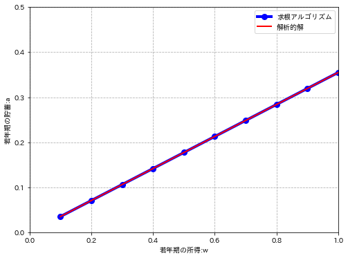

```python
fig, ax = plt.subplots(figsize=(8,6))
ax.plot(params.grid_w,a_nl,c="b",marker="o",lw=4,ms=8,label="求根アルゴリズム")
ax.plot(params.grid_w,a_cfs,c="r",lw=2,label="解析的解")
ax.set(xlabel="若年期の所得:w",ylabel="若年期の貯蓄:a",xlim=(0,1.0),ylim=(0,0.5))
ax.legend(loc="upper right")
ax.grid(ls="--")
plt.show()
```